# Tractament del dataset de passatgers del Titànic

```r
library(car)
# Procedim a comprovar la homoscedasticitat de la variable Age, tenint en compte que ens interessa conèixer la seva relació amb Survived.
leveneTest(Age ~ Survived, data = complet)
```

```
## Levene's Test for Homogeneity of Variance (center = median)
##        Df F value  Pr(>F)
## group   1  4.5693 0.03282 *
##       889
## ---
## Signif. codes:  0 '***' 0.001 '**' 0.01 '*' 0.05 '.' 0.1 ' ' 1
```

```r
fligner.test(Age ~ Survived, data = complet)
```

```
##
##  Fligner-Killeen test of homogeneity of variances
##
## data:  Age by Survived
## Fligner-Killeen:med chi-squared = 7.4739, df = 1, p-value = 0.00626
```

```r
# Procedim a comprovar la homoscedasticitat de la variable Fare, tenint en compte que ens interessa conèixer la seva relació amb Survived.
leveneTest(Fare ~ Survived, data = complet)
```

```
## Levene's Test for Homogeneity of Variance (center = median)
##        Df F value    Pr(>F)
## group   1    45.1 3.337e-11 ***
##       889
## ---
## Signif. codes:  0 '***' 0.001 '**' 0.01 '*' 0.05 '.' 0.1 ' ' 1
```

```r
fligner.test(Fare ~ Survived, data = complet)
```

```
##
##  Fligner-Killeen test of homogeneity of variances
##
## data:  Fare by Survived
## Fligner-Killeen:med chi-squared = 96.253, df = 1, p-value < 2.2e-16
```

Ara comprovarem les relacions amb les variables no numèriques o amb molts pocs valors únics en els que la correlació no ens serveix.

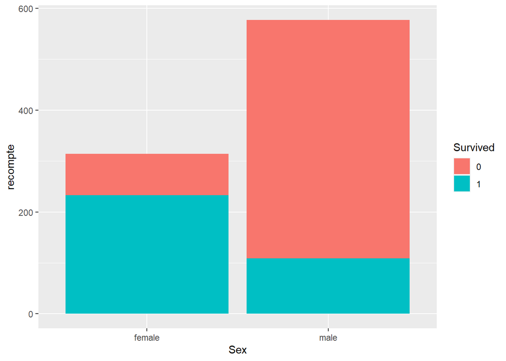

```r
# Primer observem la relació del sexe del passatger amb survived.
ggplot(data=complet[1:supervivents,],aes(x=Sex,fill=Survived))+geom_bar()+ylab("recompte")
```

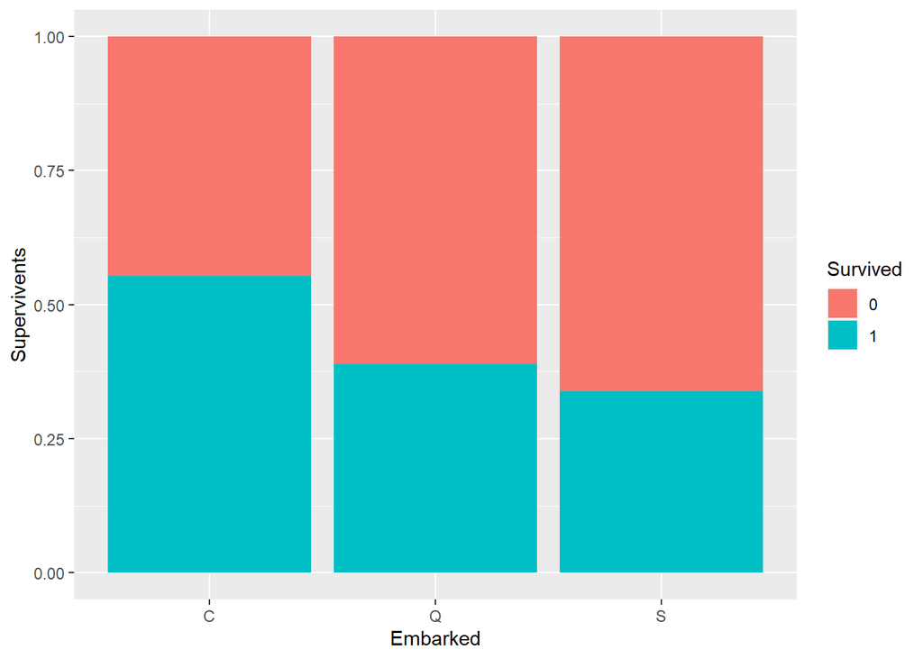

```r
# Ara compararem amb els ports de sortida (Embarked) i veiem que hi ha més probabilitats de sobreviure si has partit de Cherbourg que de la resta, a la resta no arriba al 50% i aquí es supera, tot i no haver-hi una gran diferència.
ggplot(data = complet[1:supervivents,],aes(x=Embarked,fill=Survived))+geom_bar(position="fill")+ylab("Supervivents")
```

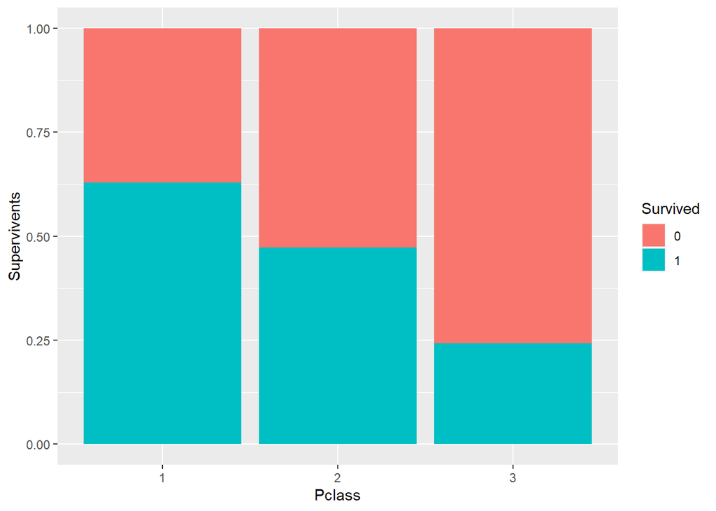

```r
# Compararem les possibilitats de sobreviure segons la classe ara, com podem veure a menor classe social menors possibilitats de sobreviure.
ggplot(data = complet[1:supervivents,],aes(x=Pclass,fill=Survived))+geom_bar(position="fill")+ylab("Supervivents")
```

Ara compararem les possibilitats de supervivència amb les dues variables de familiars, primer amb els germans/esposes i després amb els fills/pares, es pot veure una tendència similar.

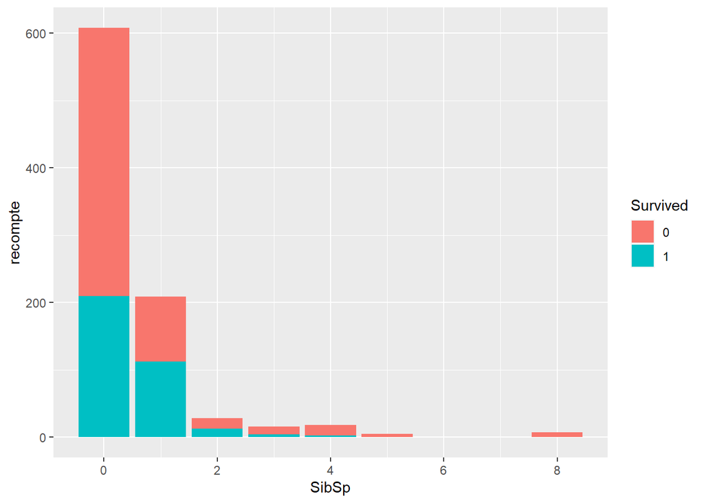

```r
ggplot(data = complet[1:supervivents,],aes(x=SibSp,fill=Survived))+geom_bar()+ylab("recompte")
```

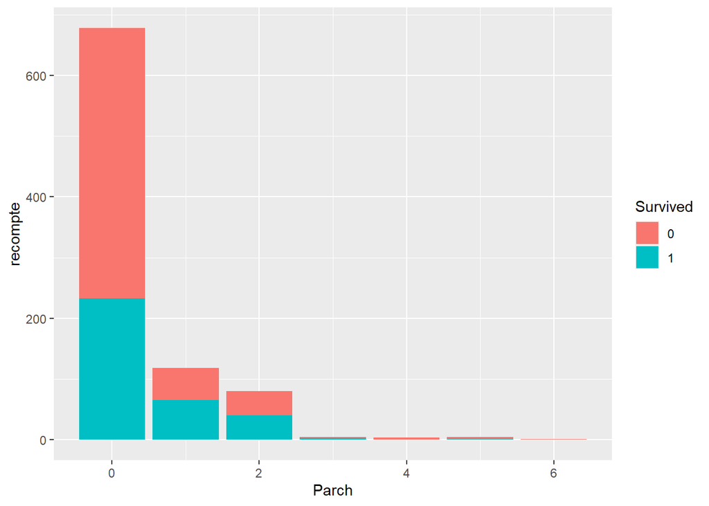

```r
ggplot(data = complet[1:supervivents,],aes(x=Parch,fill=Survived))+geom_bar()+ylab("recompte")
```

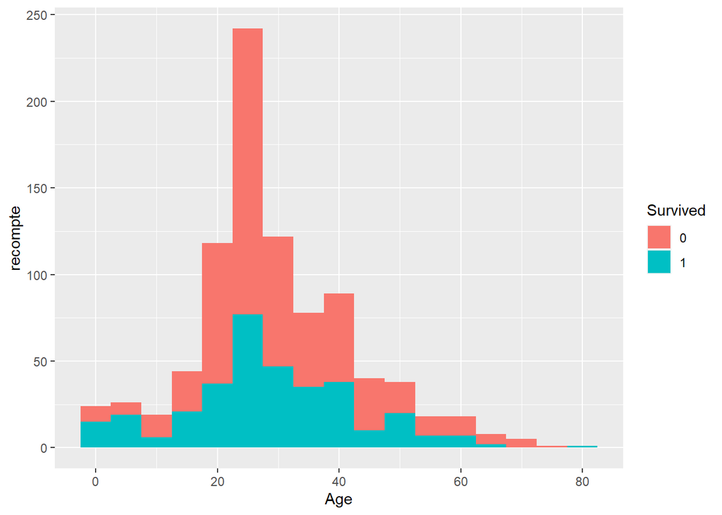

```r
# Comparació amb l'edat: com hi ha tantes dades les hem ajuntat de cinc en cinc anys, i com es veia tot molt baix en qüestió de números ho hem posat en percentatge al segon gràfic, així s'observa millor per franges el percentatge de supervivents, però sense un dels dos gràfics no té sentit, ja que per exemple mirant el segon veiem que tots els majors de 80 han sobreviscut, en canvi amb l'altre gràfic veiem que només és 1 passatger.

ggplot(data = complet[1:supervivents,],aes(x=Age,fill=Survived))+geom_histogram(binwidth =5)+ylab("recompte")
```

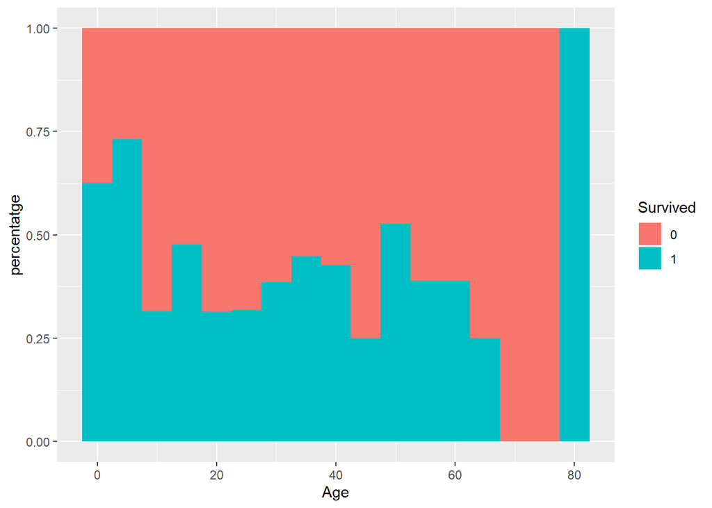

```r
ggplot(data = complet[1:supervivents,],aes(x=Age,fill=Survived))+geom_histogram(binwidth = 5, position= "fill")+ylab("percentatge")
```

Una altra opció per comprovar la relació entre la variable de classe (pclass) del dataset i la variable survived és fer el test Chi-Square. Aquest test ens ajuda a veure la correlació entre 2 variables categòriques.

```r
# Farem servir el dataset sense valors nuls a la variable survived.
chisq.test(complet[1:supervivents,]$Survived, complet[1:supervivents,]$Pclass)
```

```
##
##  Pearson's Chi-squared test
##
## data:  complet[1:supervivents, ]$Survived and complet[1:supervivents, ]$Pclass
## X-squared = 102.89, df = 2, p-value < 2.2e-16
```

Amb un p-value tan baix rebutgem la hipòtesi nul·la, podem concloure que les variables no són independents.